# QFISH Document

Ean Brinker

2023-05-15

## QFISH Database Assignment

```r
library(tidyverse)
```

```r
library(ggplot2)
library(ggtext)
library(dplyr)
library(readr)
```

For this assignment, I have selected the Otter Trawl fisheries database, looking at the number of licenses, days, and tonnes of catch by species and region. This dataset spans from subtropical Queensland through the Torres Strait and into the Gulf of Carpentaria, and runs from 1990-present.

```r
QFISH.otter.trawl <- read_csv("C:/Users/eanbr/Desktop/JCU Masters/Semester 3/MB5370 Techniques in Marine Science 1/github/mb5370/Data Science Module/data/QFISH.otter.trawl.csv", col_names = TRUE, na = "N/A", col_types = cols(Species = col_character(),
  Region = col_character(),
  Licences = col_number(),
  Days = col_number(),
  Tonnes = col_number()))

# After running the original read.csv file, I discovered lots of missing numeric data. I tried re-running using the readr package to specify column names instead of a mutate, but I still ran into an issue where the Tonnes column was limited to certain data ranges. Under the column type integer, the column only allowed data from 0-200. Under the double type, the limit increased to 1000, but was still limited. Only the number col_type allowed the data to expand appropriately. I still want it as a tibble, though.

qfish <- as_tibble(QFISH.otter.trawl)

qfish
```

```
## # A tibble: 1,288 × 5
##    Species                       Region                Licences   Days  Tonnes
##    <chr>                         <chr>                    <dbl>  <dbl>   <dbl>
##  1 Amberjack                     Mapstone - Townsville        6      6    0.31
##  2 Bait fish                     Mapstone - Townsville        7     13    0.4
##  3 Barramundi                    Mapstone - Townsville       NA     NA   NA
##  4 Bream - black (luderick)      Mapstone - Townsville       NA     NA   NA
##  5 Bream - bony (herring)        Mapstone - Townsville       NA     NA   NA
##  6 Bug - honey                   Mapstone - Townsville       11     14    0.64
##  7 Bugs - Balmain                Mapstone - Townsville      201   6060  172
##  8 Bugs - moreton bay            Mapstone - Townsville      621 238632 6485.
##  9 Bugs - unspecified            Mapstone - Townsville      166   4952   98.8
## 10 Butterflybream -  unspecified Mapstone - Townsville      135   7519   89.9
## # ℹ 1,278 more rows
```

Now let’s look at some data.

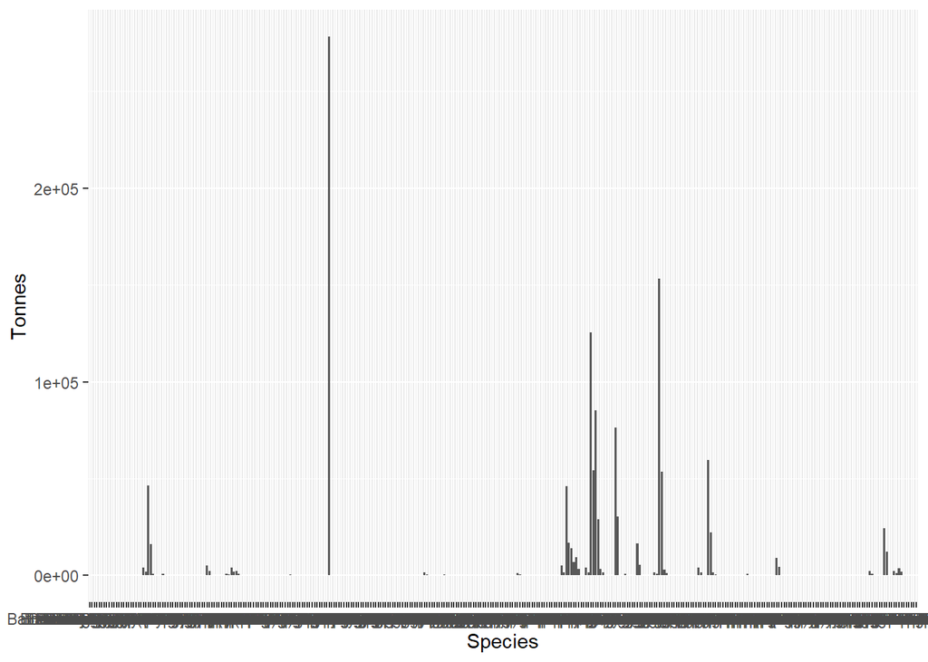

```r
ggplot(data = qfish)+
  geom_col(aes(x = Species, y = Tonnes))
```

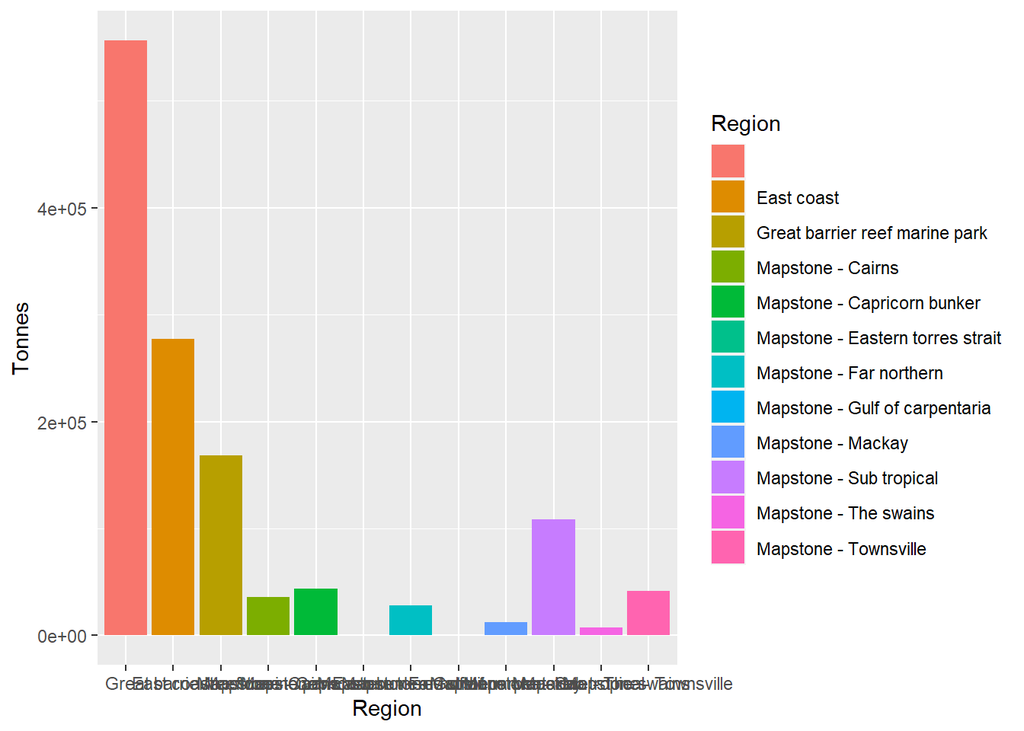

```r
# Okay, so we have a little too  many species to look at that.

TbyR <- ggplot(data = qfish)+
  geom_col(aes(x = Region, y = Tonnes, fill = Region))
TbyR
```

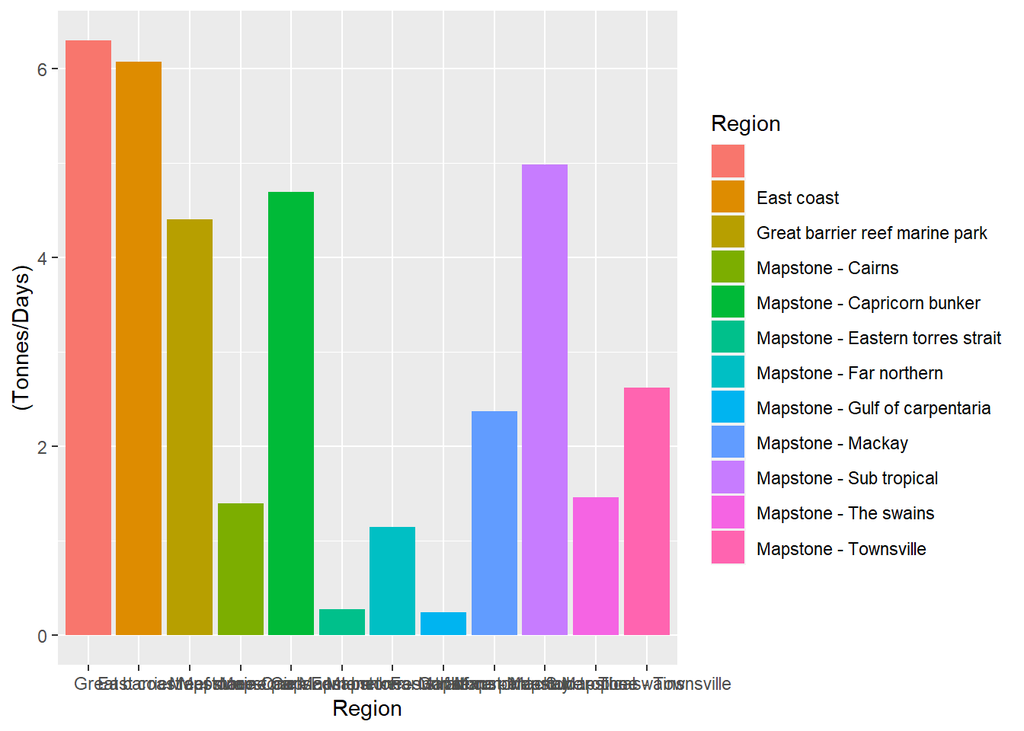

```r
# Could be something there.

CatchRate <- ggplot(qfish) +
  geom_col(aes(x = Region, y = (Tonnes/Days), fill = Region))
CatchRate
```

Current plan: plot a map of Australia with the regions on it that has the top species (by tonnage) for that fishery region mapped. Bonus: the dots for each species are sized by tonnage and colored by species. Bonus Bonus: create a second chart, nearly identical but from the dataset that has the highest catch rate (tonnes per day). Bonus bonus bonus: Do top three, instead of largest.

We need:

- A map of Australia
- Coordinate data for the regions
- A filtered database containing only the largest per region

Let’s begin.

```r
realfish <- filter(qfish, Species != "Unknown", Species != "Unknown Total", Species != "Grand Total") # Our original dataset has some unknowns that may take over our real data. Let's use only species we have an ID for.

top3 <- slice_max(realfish, order_by = Tonnes, by = Region, n=3) # It was significantly easier than expected to take the top three values, grouped by region and ordered by tonnes. It does include some regions we do not like, however--we don't want the total for just the East Coast or GBR Marine Park for this analysis.

ref3 <- filter(top3, Region != "East coast", Region != "Great barrier reef marine park" )

# Now, we are going to assign a Latitude and Longitude value for each region. Note that these values are based on visual estimates of coastal areas based on the Mapstone Categories and is for visualization purposes only. I derived these values from the coordinate function on Google Earth.
latlong <- tribble(
  ~Region, ~Latitude, ~Longitude,
  'Mapstone - Cairns', 146.26533, -16.79403,
  'Mapstone - Capricorn bunker', 151.95576, -23.45006,
  'Mapstone - Far northern', 145.01776, -14.15892,
  'Mapstone - Mackay', 150.54438, -20.72121,
  'Mapstone - Sub tropical', 154.26726, -24.82636,
  'Mapstone - The swains', 152.47458, -21.98121,
  'Mapstone - Townsville', 147.70691, -18.81202,
  '', 142.7983, -20.80399,
  'Mapstone - Eastern torres strait', 143.39179, -10.68325,
  'Mapstone - Gulf of carpentaria', 139.17597, -14.85047
)

llref3 <- left_join(ref3,latlong, by = "Region")

llref3 # Now we have our data that can be spatially referenced on a map of Australia.
```

```
## # A tibble: 30 × 7
##    Species              Region         Licences   Days Tonnes Latitude Longitude
##    <chr>                <chr>             <dbl>  <dbl>  <dbl>    <dbl>     <dbl>
##  1 Prawn - tiger        Mapstone - To…      644 173403 11961.     148.     -18.8
##  2 Bugs - moreton bay   Mapstone - To…      621 238632  6485.     148.     -18.8
##  3 Prawn - king         Mapstone - To…      573 101439  5503      148.     -18.8
##  4 Prawn - eastern king Mapstone - Th…       89  25290  4519.     152.     -22.0
##  5 Prawn - king         Mapstone - Th…      175  15907  1987.     152.     -22.0
##  6 Scallop - saucer     Mapstone - Th…      186   2300   176.     152.     -22.0
##  7 Prawn - eastern king Mapstone - Su…      476 290574 37373.     154.     -24.8
##  8 Prawn - king         Mapstone - Su…      655 252983 14821.     154.     -24.8
##  9 Whiting - stout      Mapstone - Su…       98   9908 12123.     154.     -24.8
## 10 Prawn - banana       Mapstone - Ma…      303  12804  2304.     151.     -20.7
## # ℹ 20 more rows
```

#### Mapping our data

Loading in our mapping packages:

```r
library(sf)
library(terra)
library(tmap)
```

These packages are commonly used for creating spatial maps in R. Terra provides us with a number of useful datasets and imagery, while sf allows for conversion to spatial data and tmap is our base mapping tool. In order to use these mapping features, we need to do some conversions.

Converting our data into spatially-referenced data:

```r
sfref3 <- st_as_sf(llref3, coords = c("Latitude", "Longitude"), crs=4326) # Using the WGS 84 coordinate reference system. WGS 84 is one of the most common reference systems for mapping data.
```

The basis of our map plot relies on simple coastline and shelf polygons of the coast of Australia, rather than a detailed and distracting interactive map. This requires shapefiles that include those polygons–thankfully, we accessed those shapes in class.

Accessing our shapefiles:

```r
aus <- st_read("C:/Users/eanbr/Desktop/JCU Masters/Semester 3/MB5370 Techniques in Marine Science 1/github/mb5370/Data Science Module/data/data-for-course/spatial-data/Aussie/Aussie.shp")
# Notes: something about the st_read function completely breaks the relative file paths we were using originally after the first time you save and close R. So far, the only solution I have found is to use the explicit file path.

# Both Aus and Shelf data are downloaded from this link: https://drive.google.com/file/d/1cXeH25aUH-YX5stDRdMdfEVCOF0r_gzB/view

aus
```

```
## Simple feature collection with 8 features and 1 field
## Geometry type: MULTIPOLYGON
## Dimension:     XY
## Bounding box:  xmin: 112.9211 ymin: -43.63192 xmax: 153.6389 ymax: -9.229614
## Geodetic CRS:  WGS 84
##   adm                       geometry
## 1 NSW MULTIPOLYGON (((141.0029 -3...
## 2 Vic MULTIPOLYGON (((140.9659 -3...
## 3 QLD MULTIPOLYGON (((153.5522 -2...
## 4  SA MULTIPOLYGON (((129.0013 -2...
## 5  WA MULTIPOLYGON (((129.0012 -1...
## 6 Tas MULTIPOLYGON (((148.3096 -4...
## 7  NT MULTIPOLYGON (((137.9962 -1...
## 8 ACT MULTIPOLYGON (((149.1253 -3...
```

```r
shelf <- st_read("C:/Users/eanbr/Desktop/JCU Masters/Semester 3/MB5370 Techniques in Marine Science 1/github/mb5370/Data Science Module/data/data-for-course/spatial-data/aus_shelf/aus_shelf.shp")
shelf
```

```
## Simple feature collection with 1 feature and 1 field
## Geometry type: MULTIPOLYGON
## Dimension:     XY
## Bounding box:  xmin: 112.2242 ymin: -44.1284 xmax: 153.8942 ymax: -8.8798
## Geodetic CRS:  GRS 1980(IUGG, 1980)
##   FID                       geometry
## 1   0 MULTIPOLYGON (((112.2267 -2...
```

Once we have our shapefiles, we can begin using tmap. The tm_shape function acts much like a ggplot, where additional lines of code are added on in layers to our map. We do need to set the size of our chart, however, as it will default to our data size. Originally, that sounds useful, but our data includes a simple polygon of the entiretey of Australia. We just want the east coast of Queensland.

Building our map:

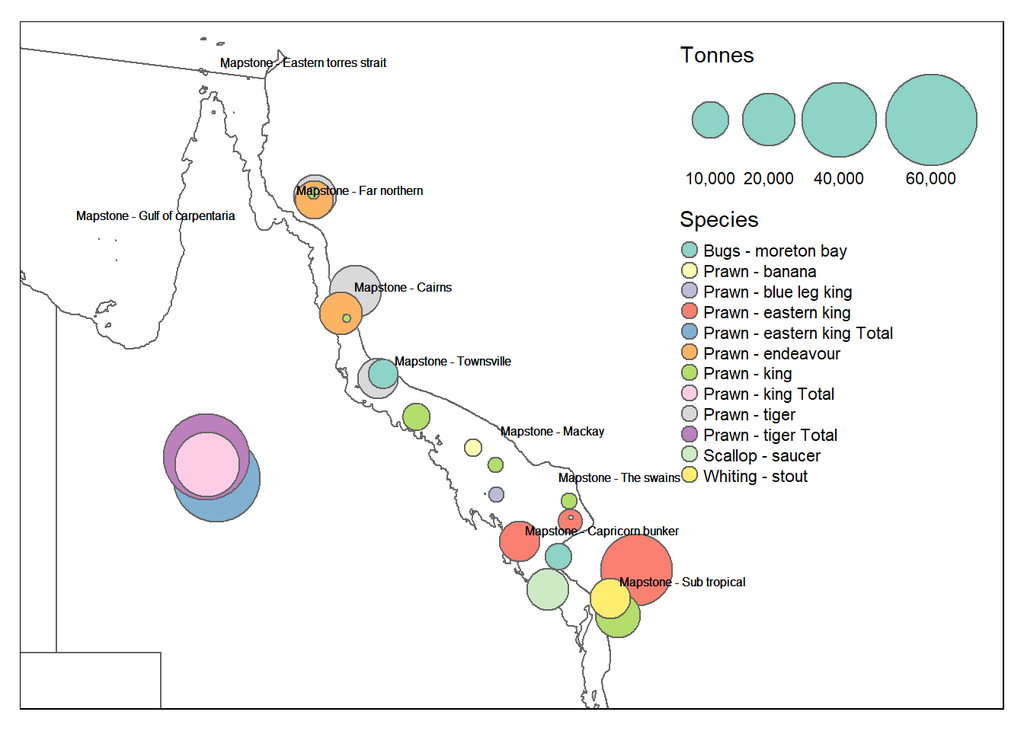

```r
# Setting our boundary box:
eastcoast = tribble(
  ~Latitude, ~Longitude,
  164.57611, -27.15727,
  137.52631, -9.16756
)

# Converting to spatially referenced data:
sfeastcoast <- st_as_sf(eastcoast, coords = c("Latitude", "Longitude"), crs = 4326)

draftmap1 <- tm_shape(shelf, bbox = sfeastcoast)+
  tm_polygons(border.alpha = 1, alpha = 0)+
  tm_shape(aus)+
  tm_polygons(border.alpha = 1, alpha = 0)+
  tm_shape(sfref3)+
  tm_bubbles(size = "Tonnes", col = "Species", jitter = 0.5, scale = 4, labels = NULL)+
  tm_text("Region", size = 1/2, xmod = 2, ymod = 1)

draftmap1
```

Looking at the resultant draft map, I see a few issues. First, without a way to cluster my data points regularly (without adding further lat-long complexity into my dataset), my largest data points are problematically overlapping. Second, several of my data values are critically undersized, particularly in the Eastern Torres Strait and Gulf of Carpentaria. The original intent to include the largest fisheries in all of Queensland was a nice touch, but poorly implemented. Let’s re-filter to just the East Coast areas, ignoring our overall totals, the Torres Strait, and the Gulf.

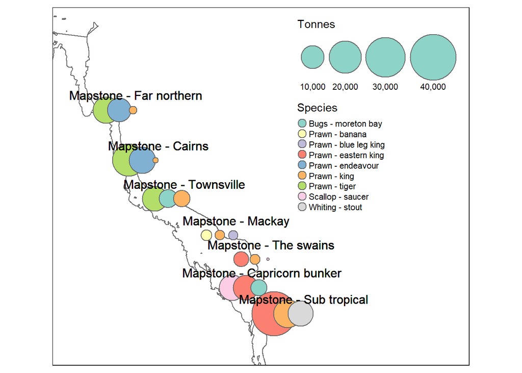

```r
# Filtering out the unusable data:
sfrefined <- filter(sfref3, Region != "Mapstone - Gulf of carpentaria", Region != "Mapstone - Eastern torres strait", Region != "")

# Let's re-map with newly redefined data. I will also resize our bounding box.

gbrbox = tribble(
  ~Latitude, ~Longitude,
  164.57611, -27.15727,
  142.52631, -9.16756
)

# Converting our new east-coast/gbr bounding box:
sfgbrbox <- st_as_sf(gbrbox, coords = c("Latitude", "Longitude"), crs = 4326)

# Second draft of our map:
draftmap2 <- tm_shape(shelf, bbox = sfgbrbox)+
  tm_polygons(border.alpha = 1, alpha = 0)+
  tm_shape(aus)+
  tm_polygons(border.alpha = 1, alpha = 0)+
  tm_shape(sfrefined)+
  tm_bubbles(size = "Tonnes", col = "Species", xmod = c(0,.9,1.8), scale = 4, labels = NULL, )+
  tm_text("Region", size = 1, xmod = 2, ymod = 1)

draftmap2
```

That is looking great–final edits to come. I want to move my legend over onto the mainland so we can see more of QLD and less ocean. Additionally, my map is missing some key design elements, like a title.

```
## The legend is too narrow to place all symbol sizes.
```

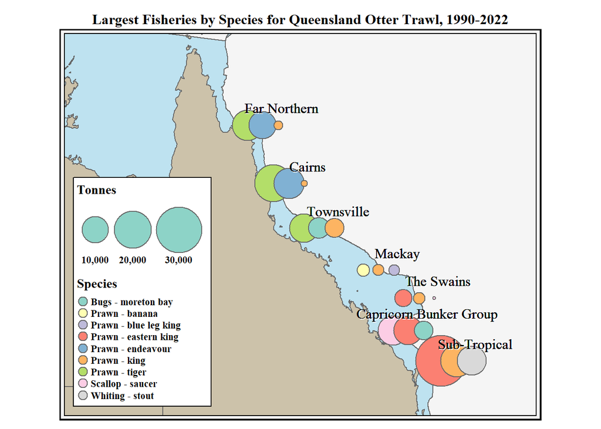

```r
# Redefining my bounding box to show more of Australia and less of the open ocean:

ausbox = tribble(
  ~Latitude, ~Longitude,
  158.57611, -27.15727,
  136.52631, -10.16756
)

sfausbox <- st_as_sf(ausbox, coords = c("Latitude", "Longitude"), crs = 4326)

# Let's create a better label vector and join it to our data. Our current regions are messy:
reglabs <- tribble(
  ~Region, ~Label,
  'Mapstone - Cairns',"Cairns",
  'Mapstone - Capricorn bunker',"Capricorn Bunker Group",
  'Mapstone - Far northern',"Far Northern",
  'Mapstone - Mackay',"Mackay",
  'Mapstone - Sub tropical', "Sub-Tropical",
  'Mapstone - The swains', "The Swains",
  'Mapstone - Townsville',"Townsville")

sfrefined2 <- left_join(sfrefined,reglabs, by = 'Region')


# Returning to our map:
draftmap3 <- tm_shape(shelf, bbox = sfausbox)+
  tm_polygons(border.alpha = 1, alpha = 0.5, col="skyblue")+
  tm_shape(aus)+
  tm_polygons(border.alpha = 1, alpha = 0.7, col = "tan")+
  tm_shape(sfrefined2)+
  tm_bubbles(size = "Tonnes", col = "Species", xmod = c(0,.9,1.8), scale = 4, labels = NULL)+
  tm_text("Label", size = 1, xmod = 2, ymod = 1, shadow = TRUE)+
  tm_layout(main.title = "Largest Fisheries by Species for Queensland Otter Trawl, 1990-2022", main.title.position = "center", legend.position = c("left", "bottom"), legend.frame = TRUE, legend.bg.color = "white", bg.color = "gray96", frame.double.line = TRUE, frame.lwd = 1, fontfamily = "serif", fontface = "bold", main.title.size = 1)

draftmap3 # Looks great!
```

With those final edits, our plot is complete. We can see the largest fisheries by region, the species that compose them, and where along the coast those fisheries disappear. In the north, endeavour prawns and tiger prawns dominate the fisheries, but south of Townsville, Eastern king prawns take their place. The standard king prawns are caught up and down the coast, similar to Moreton Bay bugs. This chart is a summation of total catch, and may not reflect the year-to-year variations in harvest.

LEGACY CODE:

```r
# qfish <- as_tibble(QFISH.otter.trawl)

# qfish # As the default viewing width of tibbles is five columns, we do not need to adjust the viewing width for this dataset. However, several of our columns are characters, not integers.

# mutate <- qfish %>% mutate_at('Licences', as.numeric)
# mutate2 <- mutate %>% mutate_at('Days', as.numeric)
# prettyfish <- mutate2 %>% mutate_at('Tonnes', as.numeric)

# prettyfish
# After these mutations, our dataset should be ready to use.
```